# Motivating Facts

2025-10-14

# 0. Data description

## 0-A Variable definitions

Here we run the following first-pass regression, either as a time-series regession for individual industry or as a panel regression pooling all 42 industries:

$$\begin{align}
\Delta y_{i,t}=\alpha+\beta \Delta \mathbf{X}_{i,t}+\gamma
\mathbf{S}_{t}+\epsilon_{it}
\end{align}$$

Where $y\in \{ PROB, CS, MKTLEV, D2D, EXRET, SIGMA\}$ are asset pricing quantities, $\mathbf{X}_{i,t}=[EBITDA_{i,t},NIMTA_{i,t},CASHMTA_{i,t},ASSETS_{i,t},PROFIT_{i,t},SALES_{i,t}]'$ is a vector of fundamental shocks. $\mathbf{S}_t$ is one of the ten aggregate shocks IP, CFNAI, EPU, UNRATE, DeltaLiq, MACROU, REALU, NGDP, FEDFUNDS, ICR. We calculate cross-industry conditional correlation controlling for aggregate shocks for industry-pair $\{i, j\}$ as the unconditional correlation between residuals.

$$\begin{align}
\rho_k^{Excess}=\mathbb{C}orr(\epsilon_{it},\epsilon_{jt})
\end{align}$$

Standard errors are calculated as $se(\rho)=\sqrt{\frac{1-\rho^2}{T-2}}$ for individual pairs, and using bootstrap for average correlation across pair groups. The bootstrap block length is 4.

# 1. 18 unrelated industsry pairs

## Total Correlations Table A2, A3.

### Total Correlations Unrelated Pairs Details (A2, A3)

#### Funda Corr Unrelated Industry Pairs A2

Total Fundamental Correlations Unrelated Industry Pairs

| pairname | EBITDA | EARN1Q | NIMTA | CASHMTA | ASSETS | PROFIT | SALES |
| --- | --- | --- | --- | --- | --- | --- | --- |
| Food_Smoke | -0.008 | -0.074 | -0.177 | 0.191 | 0.188 | 0.278 | 0.262 |
|  | (0.083) | (0.083) | (0.082) | (0.082) | (0.082) | (0.08) | (0.08) |
| Smoke_MedEq | 0.059 | 0.229 | 0.117 | 0.050 | 0.166 | 0.166 | 0.254 |
|  | (0.083) | (0.081) | (0.082) | (0.083) | (0.082) | (0.082) | (0.08) |
| Smoke_Chems | -0.102 | 0.175 | 0.174 | 0.061 | 0.043 | 0.126 | 0.108 |
|  | (0.083) | (0.082) | (0.082) | (0.083) | (0.083) | (0.082) | (0.083) |
| Smoke_BusSv | -0.028 | -0.165 | -0.004 | -0.033 | 0.122 | 0.084 | 0.106 |
|  | (0.083) | (0.082) | (0.083) | (0.083) | (0.082) | (0.083) | (0.083) |
| Smoke_Chips | 0.008 | -0.059 | -0.131 | 0.061 | -0.012 | 0.100 | 0.060 |
|  | (0.083) | (0.083) | (0.082) | (0.083) | (0.083) | (0.083) | (0.083) |
| Smoke_Paper | -0.045 | 0.304 | 0.103 | 0.102 | 0.144 | 0.047 | 0.053 |
|  | (0.083) | (0.079) | (0.083) | (0.083) | (0.082) | (0.083) | (0.083) |
| Smoke_Trans | -0.133 | 0.177 | 0.115 | 0.081 | -0.008 | -0.089 | 0.026 |
|  | (0.082) | (0.082) | (0.082) | (0.083) | (0.083) | (0.083) | (0.083) |
| Smoke_Whlsl | -0.103 | 0.094 | 0.052 | 0.059 | 0.111 | 0.172 | 0.187 |
|  | (0.083) | (0.083) | (0.083) | (0.083) | (0.083) | (0.082) | (0.082) |
| Toys_Gold | 0.039 | 0.139 | 0.045 | -0.003 | 0.015 | 0.021 | -0.014 |
|  | (0.083) | (0.083) | (0.083) | (0.083) | (0.083) | (0.083) | (0.083) |
| Fun_Ships | -0.030 | -0.163 | 0.029 | 0.164 | -0.059 | -0.011 | -0.097 |
|  | (0.083) | (0.084) | (0.083) | (0.082) | (0.083) | (0.083) | (0.083) |
| Hlth_Gold | 0.003 | -0.086 | -0.159 | -0.129 | 0.046 | -0.012 | -0.021 |
|  | (0.083) | (0.083) | (0.082) | (0.082) | (0.083) | (0.083) | (0.083) |
| Txtls_Ships | -0.093 | 0.107 | 0.064 | 0.142 | 0.076 | -0.107 | 0.081 |
|  | (0.083) | (0.084) | (0.083) | (0.082) | (0.083) | (0.083) | (0.083) |
| Cnstr_Gold | -0.056 | -0.030 | -0.057 | 0.019 | -0.031 | -0.003 | 0.034 |
|  | (0.083) | (0.083) | (0.083) | (0.083) | (0.083) | (0.083) | (0.083) |
| FabPr_Gold | -0.083 | -0.026 | -0.030 | 0.041 | 0.032 | -0.049 | 0.000 |
|  | (0.083) | (0.083) | (0.083) | (0.083) | (0.083) | (0.083) | (0.083) |
| Guns_Gold | -0.017 | 0.021 | -0.114 | -0.041 | 0.054 | 0.148 | 0.219 |
|  | (0.083) | (0.083) | (0.083) | (0.083) | (0.083) | (0.082) | (0.081) |
| Gold_Mines | 0.084 | 0.048 | -0.001 | 0.163 | 0.047 | 0.104 | 0.202 |
|  | (0.083) | (0.083) | (0.083) | (0.082) | (0.083) | (0.083) | (0.081) |
| Gold_Coal | -0.001 | 0.109 | 0.031 | -0.036 | 0.144 | 0.019 | -0.088 |
|  | (0.083) | (0.083) | (0.083) | (0.083) | (0.082) | (0.083) | (0.083) |
| Gold_PerSv | 0.179 | 0.006 | -0.043 | 0.072 | 0.034 | -0.016 | -0.080 |
|  | (0.082) | (0.083) | (0.083) | (0.083) | (0.083) | (0.083) | (0.083) |
| Frequency sig 5% | 0.056 | 0.278 | 0.056 | 0.222 | 0.222 | 0.222 | 0.278 |
| Average | -0.018 | 0.045 | 0.001 | 0.054 | 0.062 | 0.054 | 0.072 |

#### Funda Corr Unrelated Industry Pairs A3

Total Fundamental Correlations Unrelated Industry Pairs

| pairname | PROB | MKTLEV | CS5y | EXRET | SIGMA |
| --- | --- | --- | --- | --- | --- |
| Food_Smoke | 0.402 | 0.614 | 0.757 | 0.710 | 0.638 |
|  | (0.076) | (0.066) | (0.072) | (0.058) | (0.064) |
| Smoke_MedEq | 0.313 | 0.526 | 0.719 | 0.533 | 0.634 |
|  | (0.079) | (0.071) | (0.076) | (0.07) | (0.064) |
| Smoke_Chems | -0.008 | 0.318 | 0.769 | 0.404 | 0.574 |
|  | (0.083) | (0.079) | (0.07) | (0.076) | (0.068) |
| Smoke_BusSv | 0.013 | 0.332 | 0.695 | 0.159 | 0.614 |
|  | (0.083) | (0.078) | (0.079) | (0.082) | (0.066) |
| Smoke_Chips | -0.187 | 0.241 | 0.746 | 0.148 | 0.598 |
|  | (0.082) | (0.081) | (0.073) | (0.082) | (0.067) |
| Smoke_Paper | -0.055 | 0.373 | 0.758 | 0.468 | 0.578 |
|  | (0.083) | (0.077) | (0.072) | (0.073) | (0.068) |
| Smoke_Trans | 0.002 | 0.334 | 0.769 | 0.444 | 0.601 |
|  | (0.083) | (0.078) | (0.07) | (0.074) | (0.066) |
| Smoke_Whlsl | 0.029 | 0.435 | 0.715 | 0.491 | 0.636 |
|  | (0.083) | (0.075) | (0.077) | (0.072) | (0.064) |
| Toys_Gold | 0.020 | 0.107 | 0.338 | 0.038 | 0.631 |
|  | (0.083) | (0.083) | (0.139) | (0.083) | (0.064) |
| Fun_Ships | 0.380 | 0.434 | 0.584 | 0.489 | 0.709 |
|  | (0.077) | (0.075) | (0.109) | (0.072) | (0.059) |
| Hlth_Gold | 0.068 | 0.032 | 0.461 | 0.030 | 0.641 |
|  | (0.083) | (0.083) | (0.125) | (0.083) | (0.064) |
| Txtls_Ships | 0.381 | 0.600 | 0.281 | 0.648 | 0.748 |
|  | (0.077) | (0.066) | (0.215) | (0.063) | (0.055) |
| Cnstr_Gold | 0.092 | 0.137 | 0.396 | 0.106 | 0.712 |
|  | (0.083) | (0.082) | (0.13) | (0.083) | (0.058) |
| FabPr_Gold | 0.039 | 0.141 | -0.021 | 0.112 | 0.620 |
|  | (0.083) | (0.082) | (0.192) | (0.083) | (0.065) |
| Guns_Gold | 0.161 | 0.031 | 0.380 | 0.085 | 0.622 |
|  | (0.082) | (0.083) | (0.133) | (0.083) | (0.065) |
| Gold_Mines | 0.314 | 0.381 | 0.621 | 0.391 | 0.797 |
|  | (0.079) | (0.077) | (0.112) | (0.076) | (0.05) |
| Gold_Coal | 0.123 | 0.297 | 0.289 | 0.278 | 0.657 |
|  | (0.082) | (0.079) | (0.14) | (0.08) | (0.063) |
| Gold_PerSv | 0.106 | 0.005 | 0.428 | 0.013 | 0.646 |
|  | (0.083) | (0.083) | (0.128) | (0.083) | (0.063) |
| Frequency sig 5% | 0.333 | 0.778 | 0.889 | 0.667 | 1 |
| Average | 0.122 | 0.296 | 0.538 | 0.308 | 0.648 |

### Total Correlations - Robustness of A2 and A3.

| subsample | stat | EBITDA | EARN1Q | NIMTA | CASHMTA | ASSETS | PROFIT | SALES | PROB | MKTLEV | CS5y | EXRET | SIGMA |
| --- | --- | --- | --- | --- | --- | --- | --- | --- | --- | --- | --- | --- | --- |
| Full Sample | Frequency sig 5% | 0.056 | 0.278 | 0.056 | 0.222 | 0.222 | 0.222 | 0.278 | 0.333 | 0.778 | 0.889 | 0.667 | 1 |
|  |  | -0.018 | 0.045 | 0.001 | 0.054 | 0.062 | 0.054 | 0.072 | 0.122 | 0.296 | 0.538 | 0.308 | 0.648 |
|  |  | (0.021) | (0.022) | (0.018) | (0.026) | (0.026) | (0.023) | (0.029) | (0.037) | (0.041) | (0.043) | (0.054) | (0.098) |
| Pre-GFC | Frequency sig 5% | 0 | 0.167 | 0.056 | 0.111 | 0.111 | 0.056 | 0.056 | 0.278 | 0.667 | 0.5 | 0.5 | 1 |
|  |  | -0.043 | 0.028 | 0.005 | 0.068 | 0.017 | 0.005 | -0.002 | 0.098 | 0.272 | 0.347 | 0.256 | 0.507 |
|  |  | (0.024) | (0.03) | (0.023) | (0.03) | (0.033) | (0.024) | (0.029) | (0.035) | (0.063) | (0.158) | (0.074) | (0.136) |
| Post-GFC | Frequency sig 5% | 0.278 | 0.167 | 0.111 | 0.056 | 0.111 | 0.222 | 0.556 | 0.167 | 0.667 | 0.889 | 0.667 | 1 |
|  |  | 0.100 | 0.080 | 0.006 | 0.036 | 0.083 | 0.128 | 0.173 | 0.134 | 0.355 | 0.575 | 0.404 | 0.761 |
|  |  | (0.032) | (0.027) | (0.033) | (0.04) | (0.037) | (0.03) | (0.039) | (0.073) | (0.045) | (0.044) | (0.052) | (0.084) |
| Ex-Recessions | Frequency sig 5% | 0.056 | 0.222 | 0.056 | 0.167 | 0.167 | 0.167 | 0.278 | 0.333 | 0.778 | 0.889 | 0.556 | 1 |
|  |  | -0.014 | 0.053 | -0.005 | 0.081 | 0.058 | 0.050 | 0.067 | 0.115 | 0.285 | 0.474 | 0.296 | 0.525 |
|  |  | (0.03) | (0.026) | (0.017) | (0.024) | (0.032) | (0.028) | (0.031) | (0.031) | (0.045) | (0.051) | (0.054) | (0.098) |
| Annual | Frequency sig 5% | 0 | 0.278 | 0.056 | 0.111 | 0.111 | 0.056 | 0.222 | 0.389 | 0.556 | 0.833 | 0.5 | 1 |
|  |  | -0.057 | 0.105 | 0.100 | 0.079 | 0.076 | 0.036 | 0.102 | 0.240 | 0.278 | 0.696 | 0.250 | 0.821 |
|  |  | (0.065) | (0.028) | (0.038) | (0.067) | (0.061) | (0.046) | (0.051) | (0.061) | (0.083) | (0.06) | (0.08) | (0.098) |
| Biennial | Frequency sig 5% | 0.111 | 0.222 | 0.056 | 0.167 | 0.167 | 0 | 0.111 | 0.333 | 0.333 | 0.875 | 0.333 | 0.944 |
|  |  | 0.074 | 0.162 | -0.039 | 0.084 | 0.133 | 0.016 | -0.039 | 0.169 | 0.251 | 0.872 | 0.145 | 0.606 |
|  |  | (0.059) | (0.063) | (0.059) | (0.077) | (0.059) | (0.094) | (0.068) | (0.031) | (0.061) | (0.094) | (0.068) | (0.119) |

# 2. Total and Excess Correlations

## 2.1 Main table (Table 1)

Total and Excess Correlations

| group | PROB | PROB\|Eq | MKTLEV | CS5y | EXRET | SIGMA |
| --- | --- | --- | --- | --- | --- | --- |
| Total Correlation | 0.122 | 0.096 | 0.296 | 0.538 | 0.308 | 0.648 |
| Total Correlation | (0.037) | (0.035) | (0.041) | (0.043) | (0.054) | (0.098) |
| Excess Correlation | 0.110 | 0.106 | 0.188 | 0.349 | 0.187 | 0.468 |
| Excess Correlation | (0.038) | (0.028) | (0.028) | (0.077) | (0.033) | (0.069) |
| Excess Correlation Ctrl Ex Funda | 0.114 | 0.106 | 0.190 | 0.342 | 0.190 | 0.464 |
| Excess Correlation Ctrl Ex Funda | (0.037) | (0.029) | (0.029) | (0.076) | (0.033) | (0.069) |
| All Total Correlation | 0.222 | 0.148 | 0.489 | 0.546 | 0.549 | 0.803 |
| All Total Correlation | (0.062) | (0.03) | (0.042) | (0.062) | (0.043) | (0.054) |
| All Excess Correlation | 0.093 | 0.093 | 0.248 | 0.273 | 0.263 | 0.652 |
| All Excess Correlation | (0.017) | (0.02) | (0.021) | (0.061) | (0.025) | (0.049) |
| All Excess Correlation Ctrl Ex Funda | 0.093 | 0.091 | 0.247 | 0.269 | 0.263 | 0.644 |
| All Excess Correlation Ctrl Ex Funda | (0.017) | (0.02) | (0.021) | (0.061) | (0.025) | (0.047) |

## 2.1 Main table Robustness (Table 1)

### 2.1-A Sub-sample and annual Unrelated

Total and Excess Correlations

| subsample | group | PROB | PROB\|Eq | MKTLEV | CS5y | EXRET | SIGMA |
| --- | --- | --- | --- | --- | --- | --- | --- |
| Pre-GFC | Total Correlation | 0.098 | 0.096 | 0.272 | 0.347 | 0.256 | 0.507 |
| Pre-GFC | Total Correlation | (0.035) | (0.035) | (0.063) | (0.158) | (0.074) | (0.136) |
| Pre-GFC | Excess Correlation | 0.090 | 0.100 | 0.147 | NA | 0.148 | 0.394 |
| Pre-GFC | Excess Correlation | (0.035) | (0.026) | (0.036) | NA | (0.046) | (0.093) |
| Pre-GFC | Excess Correlation Ctrl Ex Funda | 0.097 | 0.104 | 0.153 | NA | 0.152 | 0.380 |
| Pre-GFC | Excess Correlation Ctrl Ex Funda | (0.033) | (0.026) | (0.038) | NA | (0.046) | (0.091) |
| Post-GFC | Total Correlation | 0.134 | 0.179 | 0.355 | 0.575 | 0.404 | 0.761 |
| Post-GFC | Total Correlation | (0.073) | (0.04) | (0.045) | (0.044) | (0.052) | (0.084) |
| Post-GFC | Excess Correlation | 0.211 | 0.192 | 0.242 | 0.352 | 0.267 | 0.429 |
| Post-GFC | Excess Correlation | (0.033) | (0.033) | (0.043) | (0.08) | (0.041) | (0.048) |
| Post-GFC | Excess Correlation Ctrl Ex Funda | 0.211 | 0.190 | 0.238 | 0.351 | 0.264 | 0.429 |
| Post-GFC | Excess Correlation Ctrl Ex Funda | (0.033) | (0.034) | (0.044) | (0.079) | (0.04) | (0.047) |
| Ex-Recessions | Total Correlation | 0.115 | 0.077 | 0.285 | 0.474 | 0.296 | 0.525 |
| Ex-Recessions | Total Correlation | (0.031) | (0.033) | (0.045) | (0.051) | (0.054) | (0.098) |
| Ex-Recessions | Excess Correlation | 0.096 | 0.085 | 0.207 | 0.355 | 0.219 | 0.383 |
| Ex-Recessions | Excess Correlation | (0.034) | (0.027) | (0.026) | (0.06) | (0.032) | (0.072) |
| Ex-Recessions | Excess Correlation Ctrl Ex Funda | 0.098 | 0.084 | 0.212 | 0.354 | 0.220 | 0.380 |
| Ex-Recessions | Excess Correlation Ctrl Ex Funda | (0.034) | (0.027) | (0.027) | (0.059) | (0.033) | (0.07) |
| Annual | Total Correlation | 0.240 | 0.191 | 0.278 | 0.696 | 0.250 | 0.821 |
| Annual | Total Correlation | (0.061) | (0.061) | (0.083) | (0.06) | (0.08) | (0.098) |
| Annual | Excess Correlation | 0.202 | 0.167 | 0.145 | 0.504 | 0.134 | 0.588 |
| Annual | Excess Correlation | (0.04) | (0.055) | (0.046) | (0.105) | (0.055) | (0.074) |
| Annual | Excess Correlation Ctrl Ex Funda | 0.179 | 0.158 | 0.147 | 0.499 | 0.127 | 0.556 |
| Annual | Excess Correlation Ctrl Ex Funda | (0.041) | (0.056) | (0.041) | (0.113) | (0.05) | (0.065) |
| Biennial | Total Correlation | 0.169 | 0.217 | 0.251 | 0.872 | 0.145 | 0.606 |
| Biennial | Total Correlation | (0.031) | (0.074) | (0.061) | (0.094) | (0.068) | (0.119) |
| Biennial | Excess Correlation | 0.126 | 0.173 | 0.054 | NA | 0.112 | 0.441 |
| Biennial | Excess Correlation | (0.041) | (0.046) | (0.042) | NA | (0.053) | (0.077) |
| Biennial | Excess Correlation Ctrl Ex Funda | 0.133 | 0.177 | 0.060 | NA | 0.112 | 0.439 |
| Biennial | Excess Correlation Ctrl Ex Funda | (0.041) | (0.047) | (0.067) | NA | (0.067) | (0.075) |

### 2.1-B Sub-sample and annual All Industries

Total and Excess Correlations

| subsample | group | PROB | PROB\|Eq | MKTLEV | CS5y | EXRET | SIGMA |
| --- | --- | --- | --- | --- | --- | --- | --- |
| Pre-GFC | Total Correlation | 0.121 | 0.115 | 0.429 | 0.381 | 0.499 | 0.746 |
| Pre-GFC | Total Correlation | (0.029) | (0.033) | (0.056) | (0.076) | (0.059) | (0.095) |
| Pre-GFC | Excess Correlation | 0.074 | 0.089 | 0.221 | NA | 0.240 | 0.634 |
| Pre-GFC | Excess Correlation | (0.016) | (0.026) | (0.021) | NA | (0.028) | (0.078) |
| Pre-GFC | Excess Correlation Ctrl Ex Funda | 0.073 | 0.086 | 0.222 | NA | 0.240 | 0.619 |
| Pre-GFC | Excess Correlation Ctrl Ex Funda | (0.016) | (0.026) | (0.021) | NA | (0.028) | (0.072) |
| Post-GFC | Total Correlation | 0.371 | 0.162 | 0.552 | 0.544 | 0.619 | 0.838 |
| Post-GFC | Total Correlation | (0.111) | (0.047) | (0.059) | (0.083) | (0.053) | (0.047) |
| Post-GFC | Excess Correlation | 0.111 | 0.094 | 0.272 | 0.268 | 0.308 | 0.555 |
| Post-GFC | Excess Correlation | (0.04) | (0.036) | (0.033) | (0.063) | (0.032) | (0.036) |
| Post-GFC | Excess Correlation Ctrl Ex Funda | 0.111 | 0.092 | 0.271 | 0.267 | 0.308 | 0.554 |
| Post-GFC | Excess Correlation Ctrl Ex Funda | (0.04) | (0.035) | (0.033) | (0.062) | (0.032) | (0.036) |
| Ex-Recessions | Total Correlation | 0.116 | 0.093 | 0.428 | 0.420 | 0.494 | 0.746 |
| Ex-Recessions | Total Correlation | (0.024) | (0.03) | (0.043) | (0.044) | (0.046) | (0.06) |
| Ex-Recessions | Excess Correlation | 0.079 | 0.075 | 0.257 | 0.323 | 0.271 | 0.616 |
| Ex-Recessions | Excess Correlation | (0.019) | (0.023) | (0.023) | (0.039) | (0.026) | (0.059) |
| Ex-Recessions | Excess Correlation Ctrl Ex Funda | 0.079 | 0.073 | 0.257 | 0.320 | 0.270 | 0.608 |
| Ex-Recessions | Excess Correlation Ctrl Ex Funda | (0.018) | (0.023) | (0.023) | (0.038) | (0.026) | (0.055) |
| Annual | Total Correlation | 0.269 | 0.141 | 0.433 | 0.738 | 0.417 | 0.894 |
| Annual | Total Correlation | (0.077) | (0.069) | (0.085) | (0.115) | (0.077) | (0.057) |
| Annual | Excess Correlation | 0.117 | 0.113 | 0.159 | 0.556 | 0.155 | 0.671 |
| Annual | Excess Correlation | (0.035) | (0.055) | (0.035) | (0.049) | (0.044) | (0.078) |
| Annual | Excess Correlation Ctrl Ex Funda | 0.113 | 0.112 | 0.180 | 0.552 | 0.165 | 0.652 |
| Annual | Excess Correlation Ctrl Ex Funda | (0.034) | (0.055) | (0.036) | (0.049) | (0.046) | (0.067) |
| Biennial | Total Correlation | 0.180 | 0.269 | 0.222 | 0.696 | 0.264 | 0.803 |
| Biennial | Total Correlation | (0.034) | (0.091) | (0.065) | (0.079) | (0.088) | (0.083) |
| Biennial | Excess Correlation | 0.102 | 0.173 | 0.041 | NA | 0.038 | 0.593 |
| Biennial | Excess Correlation | (0.027) | (0.072) | (0.021) | NA | (0.019) | (0.136) |
| Biennial | Excess Correlation Ctrl Ex Funda | 0.107 | 0.174 | 0.026 | NA | 0.023 | 0.584 |
| Biennial | Excess Correlation Ctrl Ex Funda | (0.026) | (0.073) | (0.016) | NA | (0.015) | (0.131) |

# 3. Industry pairs within market capitalization and book leverage share groups

# 3.1 Table 2 Compare Industry by Size and Book Leverage

Total and Excess Correlations by Industry Size

| group | stat | PROB | PROB\|Eq | MKTLEV | CS5y | EXRET | SIGMA |
| --- | --- | --- | --- | --- | --- | --- | --- |
| Big | corr | 0.150 | 0.159 | 0.316 | 0.533 | 0.337 | 0.742 |
| Big | se | (0.031) | (0.035) | (0.028) | (0.058) | (0.03) | (0.045) |
| Small | corr | 0.062 | 0.058 | 0.192 | 0.153 | 0.213 | 0.552 |
| Small | se | (0.016) | (0.019) | (0.024) | (0.051) | (0.024) | (0.047) |
| Big-Small | corr | 0.088 | 0.101 | 0.125 | 0.380 | 0.125 | 0.190 |
| Big-Small | se | (0.035) | (0.04) | (0.035) | (0.059) | (0.034) | (0.028) |

Total and Excess Correlations by Industry Book Leverage

| group | stat | PROB | PROB\|Eq | MKTLEV | CS5y | EXRET | SIGMA |
| --- | --- | --- | --- | --- | --- | --- | --- |
| High | corr | 0.069 | 0.079 | 0.245 | 0.299 | 0.230 | 0.592 |
| High | se | (0.022) | (0.02) | (0.032) | (0.065) | (0.026) | (0.049) |
| Low | corr | 0.116 | 0.113 | 0.244 | 0.278 | 0.264 | 0.671 |
| Low | se | (0.024) | (0.026) | (0.027) | (0.064) | (0.027) | (0.052) |
| High-Low | corr | -0.047 | -0.034 | 0.000 | 0.021 | -0.034 | -0.079 |
| High-Low | se | (0.021) | (0.022) | (0.036) | (0.035) | (0.025) | (0.018) |

Total and Excess Correlations by Industry Size - Robustness

| group | stat | subsample | PROB | PROB\|Eq | MKTLEV | CS5y | EXRET | SIGMA |
| --- | --- | --- | --- | --- | --- | --- | --- | --- |
| Big | corr | Pre-GFC | 0.077 | 0.094 | 0.274 | NA | 0.314 | 0.742 |
| Big | se | Pre-GFC | (0.022) | (0.033) | (0.028) | NA | (0.037) | (0.069) |
| Small | corr | Pre-GFC | 0.059 | 0.078 | 0.202 | NA | 0.226 | 0.505 |
| Small | se | Pre-GFC | (0.017) | (0.027) | (0.034) | NA | (0.035) | (0.071) |
| Big-Small | corr | Pre-GFC | 0.019 | 0.016 | 0.072 | NA | 0.088 | 0.237 |
| Big-Small | se | Pre-GFC | (0.025) | (0.042) | (0.042) | NA | (0.049) | (0.041) |
| Big | corr | Post-GFC | 0.306 | 0.303 | 0.382 | 0.483 | 0.400 | 0.603 |
| Big | se | Post-GFC | (0.039) | (0.04) | (0.049) | (0.062) | (0.044) | (0.035) |
| Small | corr | Post-GFC | 0.086 | 0.057 | 0.166 | 0.146 | 0.202 | 0.490 |
| Small | se | Post-GFC | (0.034) | (0.033) | (0.026) | (0.047) | (0.028) | (0.041) |
| Big-Small | corr | Post-GFC | 0.219 | 0.246 | 0.216 | 0.337 | 0.198 | 0.113 |
| Big-Small | se | Post-GFC | (0.052) | (0.058) | (0.05) | (0.059) | (0.043) | (0.038) |
| Big | corr | Ex-Recessions | 0.077 | 0.091 | 0.324 | 0.505 | 0.333 | 0.713 |
| Big | se | Ex-Recessions | (0.021) | (0.032) | (0.03) | (0.06) | (0.033) | (0.059) |
| Small | corr | Ex-Recessions | 0.080 | 0.068 | 0.200 | 0.209 | 0.226 | 0.518 |
| Small | se | Ex-Recessions | (0.019) | (0.018) | (0.026) | (0.031) | (0.026) | (0.054) |
| Big-Small | corr | Ex-Recessions | -0.003 | 0.023 | 0.124 | 0.296 | 0.107 | 0.195 |
| Big-Small | se | Ex-Recessions | (0.024) | (0.031) | (0.039) | (0.06) | (0.038) | (0.035) |
| Big | corr | Annual | 0.124 | 0.201 | 0.262 | 0.952 | 0.274 | 0.716 |
| Big | se | Annual | (0.046) | (0.081) | (0.06) | (0.097) | (0.064) | (0.075) |
| Small | corr | Annual | 0.111 | 0.064 | 0.197 | 0.194 | 0.179 | 0.552 |
| Small | se | Annual | (0.042) | (0.041) | (0.048) | (0.038) | (0.033) | (0.055) |
| Big-Small | corr | Annual | 0.013 | 0.137 | 0.065 | 0.758 | 0.095 | 0.164 |
| Big-Small | se | Annual | (0.06) | (0.071) | (0.081) | (0.091) | (0.071) | (0.042) |
| Big | corr | Biennial | 0.115 | 0.321 | 0.120 | NA | 0.146 | 0.743 |
| Big | se | Biennial | (0.053) | (0.068) | (0.045) | NA | (0.06) | (0.109) |
| Small | corr | Biennial | 0.104 | 0.128 | 0.167 | NA | 0.173 | 0.464 |
| Small | se | Biennial | (0.022) | (0.054) | (0.092) | NA | (0.078) | (0.127) |
| Big-Small | corr | Biennial | 0.010 | 0.194 | -0.047 | NA | -0.027 | 0.278 |
| Big-Small | se | Biennial | (0.057) | (0.043) | (0.062) | NA | (0.074) | (0.044) |

Total and Excess Correlations by Industry Book Leverage - Robustness

| group | stat | subsample | PROB | PROB\|Eq | MKTLEV | CS5y | EXRET | SIGMA |
| --- | --- | --- | --- | --- | --- | --- | --- | --- |
| High | corr | Pre-GFC | 0.062 | 0.095 | 0.200 | NA | 0.208 | 0.579 |
| High | se | Pre-GFC | (0.023) | (0.021) | (0.034) | NA | (0.035) | (0.075) |
| Low | corr | Pre-GFC | 0.113 | 0.101 | 0.249 | NA | 0.253 | 0.654 |
| Low | se | Pre-GFC | (0.026) | (0.025) | (0.025) | NA | (0.036) | (0.08) |
| High-Low | corr | Pre-GFC | -0.051 | -0.006 | -0.049 | NA | -0.046 | -0.076 |
| High-Low | se | Pre-GFC | (0.035) | (0.024) | (0.035) | NA | (0.038) | (0.033) |
| High | corr | Post-GFC | 0.093 | 0.071 | 0.289 | 0.298 | 0.268 | 0.483 |
| High | se | Post-GFC | (0.043) | (0.042) | (0.042) | (0.071) | (0.033) | (0.035) |
| Low | corr | Post-GFC | 0.098 | 0.106 | 0.241 | 0.279 | 0.285 | 0.566 |
| Low | se | Post-GFC | (0.048) | (0.044) | (0.046) | (0.072) | (0.034) | (0.04) |
| High-Low | corr | Post-GFC | -0.005 | -0.035 | 0.048 | 0.020 | -0.017 | -0.083 |
| High-Low | se | Post-GFC | (0.03) | (0.023) | (0.047) | (0.038) | (0.026) | (0.029) |
| High | corr | Ex-Recessions | 0.065 | 0.091 | 0.246 | 0.341 | 0.244 | 0.568 |
| High | se | Ex-Recessions | (0.023) | (0.021) | (0.032) | (0.04) | (0.029) | (0.053) |
| Low | corr | Ex-Recessions | 0.111 | 0.089 | 0.268 | 0.332 | 0.266 | 0.618 |
| Low | se | Ex-Recessions | (0.02) | (0.023) | (0.027) | (0.05) | (0.031) | (0.062) |
| High-Low | corr | Ex-Recessions | -0.046 | 0.002 | -0.022 | 0.009 | -0.022 | -0.050 |
| High-Low | se | Ex-Recessions | (0.022) | (0.023) | (0.031) | (0.041) | (0.026) | (0.023) |
| High | corr | Annual | 0.082 | 0.108 | 0.163 | 0.564 | 0.127 | 0.582 |
| High | se | Annual | (0.047) | (0.063) | (0.048) | (0.067) | (0.044) | (0.057) |
| Low | corr | Annual | 0.110 | 0.114 | 0.132 | 0.591 | 0.140 | 0.700 |
| Low | se | Annual | (0.051) | (0.084) | (0.029) | (0.1) | (0.043) | (0.092) |
| High-Low | corr | Annual | -0.028 | -0.006 | 0.031 | -0.027 | -0.014 | -0.118 |
| High-Low | se | Annual | (0.06) | (0.061) | (0.049) | (0.064) | (0.05) | (0.051) |
| High | corr | Biennial | 0.038 | 0.118 | 0.011 | NA | 0.028 | 0.483 |
| High | se | Biennial | (0.038) | (0.097) | (0.035) | NA | (0.03) | (0.1) |
| Low | corr | Biennial | 0.077 | 0.110 | -0.020 | NA | 0.003 | 0.635 |
| Low | se | Biennial | (0.027) | (0.057) | (0.017) | NA | (0.016) | (0.165) |
| High-Low | corr | Biennial | -0.039 | 0.009 | 0.031 | NA | 0.025 | -0.153 |
| High-Low | se | Biennial | (0.044) | (0.059) | (0.027) | NA | (0.026) | (0.082) |

# 3.2 Industry default correlation (Average) vs Book Leverage

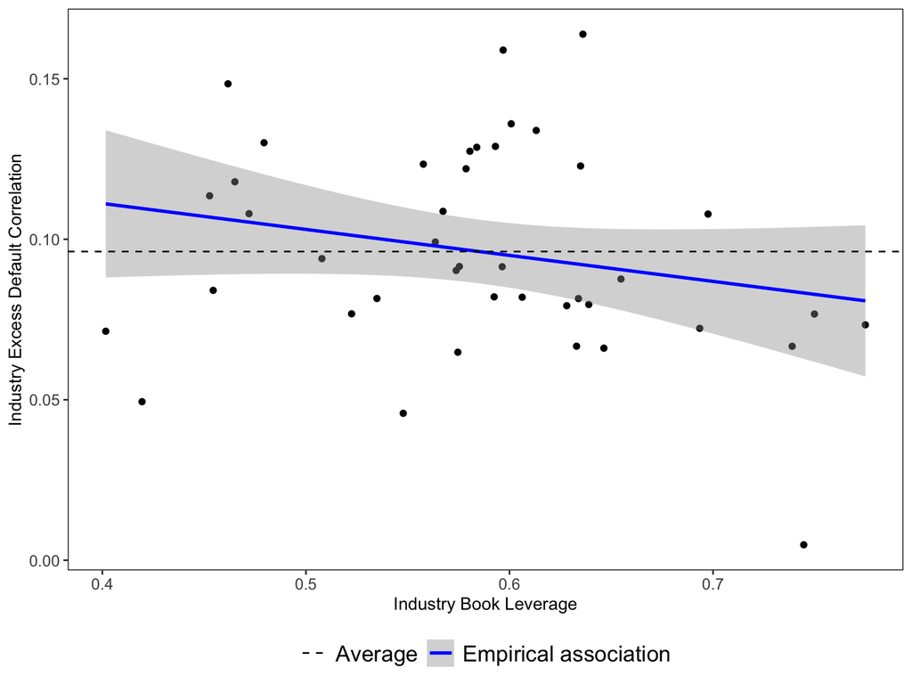